# Capstone Project_Bellabeat

Uriel Ulloa

11/4/2021

## Presentation

The following study is made for academic purposes. This is a Capstone Project for the Google Data Analysis Professional Certificate, in which the six steps of the Data Analysis Process are used.

**Title:** Google Data Analysis Capstone Project: Bellabeat Case Study  
**Author:** Uriel Ulloa  
**Date:** November 4th 2021

# Bellabeat: How Can A Wellness Technology Company Play It Smart?

### *PHASE 1: ASK*

#### **1.1.General Background**

Founded in 2013, by Urška Sršen and Sando Mur, Bellabeat is a high-tech company which aim to empower women with knowledge about their own health and habits offering them health focused smart products. For more information, please click the following link: https://bellabeat.com/about/  
From that point forward the company has grown rapidly and quickly positioned itself opening offices worldwide, having their multiple products in the catalogue of many online retailers and in their own e-commerce platform (for more information click the link to their website).  
Chief Creative Officer, Urška Sršen would like to leverage all the consumer data available and gain insight on how people are using their smart devices (FitBit Fitness Tracker Data) in order to generate data-driven recommendations for future marketing strategies

#### **1.2.Project Objectives**

1. Identify the trends in smart devices usage.
2. Generate insights about the applicability to Bellabeat customers, in particular FitBit Fitness device.
3. Deliver recommendations to the marketing team on how could the findings could improve the current campaigns.

#### **1.3.Deliverables**

1. Business Task summary
2. Description of all the data used
3. Data cleaning log
4. Analysis’s summary
5. Supporting and compelling visualizations
6. Present key findings
7. Recommendations based on findings.

#### **1.4.Business Task**

Analyze smart device usage data in to gain insight about consumer behavior trends and then apply the findings to Bella Beat FitBit Fitness Tracker Data in order to make data-driven decisions in marketing strategies.

#### **1.5.Key Stakeholder**

• **Urška Sršen:** Bellabeat’s cofounder and Chief Creative Officer. She is the one who proposed the project and the most interested in the results.  
• **Sando Mur:** Mathematician and Bellabeat’s cofounder; key member of the Bellabeat executive team.  
• **BellaBeat Marketing Analytics Team:** Team of data analyst working on collecting, analyzing, reporting and conducting the project.  
• **Bellabeat Marketing Strategies Team:** Most likely the audience wwich is going to receive the resultsm findings and recommendations of the project in order to apply it to new marketing campaigns.

### *PHASE 2: PREPARE*

#### **2.1.Data’s information**

• *FitBit Fitness Tracker Data* is an open-source data collection uploaded by *Möbius*, which was last updated on December 2020. Check out the [FitBit Fitness Tracker Dataset](https://www.kaggle.com/arashnic/fitbit) on kaggle’s community to learn more.  
• The data set is stored in 18 CSV files that have information about *Daily Activities*, *Heart Rates*, *Burned Calories*, and *Sleep* sleep patterns.  
• Datasets are generatedd in 2016, by respondents to a distributed survey via Amazon Mechanical Turk between March 12th to May 12th.  
• Thirty (30) eligible Fitbit users consented to the submission of personal tracker data.

#### **2.2.Limitations of the data**

• As stated before, the data was generated in 2016, it’s been five year since then, when people may have changed their behavior when it comes to health care.  
• There is no possible way to guarantee the integrity and accuracy of the data collected, hence it might be safe to assume data could be biased in some way or another.  
• The sample size of 30 users is too low to apply the results to a population. Even though multiple (thousands) of records exists, it’s important to keep in mind, that came from just 30 individuals.

#### **2.3.Does the data ROCC?**

| ROOCC | MEASURE | COMMENT |
| --- | --- | --- |
| Reliable | LOW | Thirty individuals doesn’t make up for a reliable result |
| Original | LOW | Data collected is from an external source, Amazon Mechanical Turk, a-third party provider |
| Comprehensive | LOW | Metadata about the tables provided is not stated |
| Current | LOW | Data is 5 years old, which might differ from current information |
| Cited | MED | Amazon Mechanicl Turk collected the information themselves, information about their sources, parameters and method is not stated |

#### **2.4.Data selected for analysis**

The following files were selected based on a most relevant criteria for the analysis purposes:

- Fitbase Data
  - `dailyActivity_merged.csv`
  - `heartrate_seconds_merged.csv`
  - `minuteMETsNarrow_merfed.csv`
  - `sleepDay-merged.csv`
  - `weightLogInfo_meged.csv`

The tool applied for data and statistical analysis is R programming language, and R studio as the Integrated Development Environment (IDE). Later on R Markdown is used for reporting.

#### **3.1. Setting up the environment**

- The following packaged are used for:
  - `tidyverse`: Designed for data import, tidying, manipulation, visualization, and programming.
  - `lubridate`: Dealing with Dates
  - `here`: Importing files a little easier
  - `conflicted`: Handles the ambiguity with functions overlapping
  - `ggplot2` and `reshape2`: Create visualizations

```r
library(tidyverse)
library(here)
library(lubridate)
library(plyr)
```

```r
library(conflicted)
library(tidyr)
library(ggplot2)
library(reshape2)
```

Following up is important to set the priority of functions right off the bat with `conflicted`, in order to avoid any code error.

```r
conflict_prefer("count", "plyr")
```

```
## [conflicted] Will prefer plyr::count over any other package
```

```r
conflict_prefer("here", "here")
```

```
## [conflicted] Will prefer here::here over any other package
```

```r
conflict_prefer("summarize", "dplyr")
```

```
## [conflicted] Will prefer dplyr::summarize over any other package
```

```r
conflict_prefer("mutate", "dplyr")
```

```
## [conflicted] Will prefer dplyr::mutate over any other package
```

```r
conflict_prefer("filter", "dplyr")
```

```
## [conflicted] Will prefer dplyr::filter over any other package
```

```r
conflict_prefer("rename", "dplyr")
```

```
## [conflicted] Will prefer dplyr::rename over any other package
```

Now having the land prepared, data cleaning is on the way.

#### **3.2. Importing the data frames**

Using the following chunk’s code, all the data necessary for the analysis is imported.

```r
#----------------------------Daily Activity Data frame -----------------------------

daily_act_df <- read.csv(here("FitBit_Fitness_Tracker_Data_CS",
                              "dailyActivity_merged.csv"))

#---------------------------------Sleep  Data frame ----------------------------------

sleep_day_df <- read.csv(here("FitBit_Fitness_Tracker_Data_CS",
                              "sleepDay_merged.csv"))

#-----------------------------Heart Rate  Data frame ----------------------------------

heartrate_df <- read.csv(here("FitBit_Fitness_Tracker_Data_CS",
                              "heartrate_seconds_merged.csv"))

#---------------------------------Weight Data frame ----------------------------------

weight_df <- read.csv(here("FitBit_Fitness_Tracker_Data_CS",
                              "weightLogInfo_merged.csv"))

#------------------------------------METs Data frame ----------------------------------

mets_df <- read.csv(here("FitBit_Fitness_Tracker_Data_CS",
                           "minuteMETsNarrow_merged.csv"))

#----------------------------Minute Sleep Data frame ----------------------------------

min_sleep_df <- read.csv(here("FitBit_Fitness_Tracker_Data_CS",
                         "minuteSleep_merged.csv"))
```

#### **3.3. Understand the data**

Is important to preview the data we are dealing with as we get more comfortable and familiarize with it, in order to draw early conclusions. For this the `tible` function is used.

```r
tibble(daily_act_df)
```

```
## # A tibble: 940 x 15
##            Id ActivityDate TotalSteps TotalDistance TrackerDistance LoggedActivitie~
##         <dbl> <chr>             <int>         <dbl>           <dbl>            <dbl>
##  1 1503960366 4/12/2016         13162          8.5             8.5                 0
##  2 1503960366 4/13/2016         10735          6.97            6.97                0
##  3 1503960366 4/14/2016         10460          6.74            6.74                0
##  4 1503960366 4/15/2016          9762          6.28            6.28                0
##  5 1503960366 4/16/2016         12669          8.16            8.16                0
##  6 1503960366 4/17/2016          9705          6.48            6.48                0
##  7 1503960366 4/18/2016         13019          8.59            8.59                0
##  8 1503960366 4/19/2016         15506          9.88            9.88                0
##  9 1503960366 4/20/2016         10544          6.68            6.68                0
## 10 1503960366 4/21/2016          9819          6.34            6.34                0
## # ... with 930 more rows, and 9 more variables: VeryActiveDistance <dbl>,
## #   ModeratelyActiveDistance <dbl>, LightActiveDistance <dbl>,
## #   SedentaryActiveDistance <dbl>, VeryActiveMinutes <int>,
## #   FairlyActiveMinutes <int>, LightlyActiveMinutes <int>,
## #   SedentaryMinutes <int>, Calories <int>
```

```r
tibble(sleep_day_df)
```

```
## # A tibble: 413 x 5
##            Id SleepDay              TotalSleepRecor~ TotalMinutesAsl~ TotalTimeInBed
##         <dbl> <chr>                            <int>            <int>          <int>
##  1 1503960366 4/12/2016 12:00:00 AM                1              327            346
##  2 1503960366 4/13/2016 12:00:00 AM                2              384            407
##  3 1503960366 4/15/2016 12:00:00 AM                1              412            442
##  4 1503960366 4/16/2016 12:00:00 AM                2              340            367
##  5 1503960366 4/17/2016 12:00:00 AM                1              700            712
##  6 1503960366 4/19/2016 12:00:00 AM                1              304            320
##  7 1503960366 4/20/2016 12:00:00 AM                1              360            377
##  8 1503960366 4/21/2016 12:00:00 AM                1              325            364
##  9 1503960366 4/23/2016 12:00:00 AM                1              361            384
## 10 1503960366 4/24/2016 12:00:00 AM                1              430            449
## # ... with 403 more rows
```

```r
tibble(heartrate_df)
```

```
## # A tibble: 2,483,658 x 3
##            Id Time                 Value
##         <dbl> <chr>                <int>
##  1 2022484408 4/12/2016 7:21:00 AM    97
##  2 2022484408 4/12/2016 7:21:05 AM   102
##  3 2022484408 4/12/2016 7:21:10 AM   105
##  4 2022484408 4/12/2016 7:21:20 AM   103
##  5 2022484408 4/12/2016 7:21:25 AM   101
##  6 2022484408 4/12/2016 7:22:05 AM    95
##  7 2022484408 4/12/2016 7:22:10 AM    91
##  8 2022484408 4/12/2016 7:22:15 AM    93
##  9 2022484408 4/12/2016 7:22:20 AM    94
## 10 2022484408 4/12/2016 7:22:25 AM    93
## # ... with 2,483,648 more rows
```

```r
tibble(weight_df)
```

```
## # A tibble: 67 x 8
##            Id Date     WeightKg WeightPounds   Fat   BMI IsManualReport    LogId
##         <dbl> <chr>       <dbl>        <dbl> <int> <dbl> <chr>             <dbl>
##  1 1503960366 5/2/201~     52.6         116.    22  22.6 True            1.46e12
##  2 1503960366 5/3/201~     52.6         116.    NA  22.6 True            1.46e12
##  3 1927972279 4/13/20~    134.          294.    NA  47.5 False           1.46e12
##  4 2873212765 4/21/20~     56.7         125.    NA  21.5 True            1.46e12
##  5 2873212765 5/12/20~     57.3         126.    NA  21.7 True            1.46e12
##  6 4319703577 4/17/20~     72.4         160.    25  27.5 True            1.46e12
##  7 4319703577 5/4/201~     72.3         159.    NA  27.4 True            1.46e12
##  8 4558609924 4/18/20~     69.7         154.    NA  27.2 True            1.46e12
##  9 4558609924 4/25/20~     70.3         155.    NA  27.5 True            1.46e12
## 10 4558609924 5/1/201~     69.9         154.    NA  27.3 True            1.46e12
## # ... with 57 more rows
```

```r
tibble(mets_df)
```

```
## # A tibble: 1,325,580 x 3
##            Id ActivityMinute         METs
##         <dbl> <chr>                 <int>
##  1 1503960366 4/12/2016 12:00:00 AM    10
##  2 1503960366 4/12/2016 12:01:00 AM    10
##  3 1503960366 4/12/2016 12:02:00 AM    10
##  4 1503960366 4/12/2016 12:03:00 AM    10
##  5 1503960366 4/12/2016 12:04:00 AM    10
##  6 1503960366 4/12/2016 12:05:00 AM    12
##  7 1503960366 4/12/2016 12:06:00 AM    12
##  8 1503960366 4/12/2016 12:07:00 AM    12
##  9 1503960366 4/12/2016 12:08:00 AM    12
## 10 1503960366 4/12/2016 12:09:00 AM    12
## # ... with 1,325,570 more rows
```

```r
tibble(min_sleep_df)
```

```
## # A tibble: 188,521 x 4
##            Id date                 value       logId
##         <dbl> <chr>                <int>       <dbl>
##  1 1503960366 4/12/2016 2:47:30 AM     3 11380564589
##  2 1503960366 4/12/2016 2:48:30 AM     2 11380564589
##  3 1503960366 4/12/2016 2:49:30 AM     1 11380564589
##  4 1503960366 4/12/2016 2:50:30 AM     1 11380564589
##  5 1503960366 4/12/2016 2:51:30 AM     1 11380564589
##  6 1503960366 4/12/2016 2:52:30 AM     1 11380564589
##  7 1503960366 4/12/2016 2:53:30 AM     1 11380564589
##  8 1503960366 4/12/2016 2:54:30 AM     2 11380564589
##  9 1503960366 4/12/2016 2:55:30 AM     2 11380564589
## 10 1503960366 4/12/2016 2:56:30 AM     2 11380564589
## # ... with 188,511 more rows
```

As a summary:

| Data Frame | #Observations | #Fields |
| --- | --- | --- |
| Daily Activity | 940 | 15 |
| Sleep Day | 413 | 5 |
| Heart Rate | 2,483,658 | 3 |
| Weight | 67 | 8 |
| METs | 1,325,580 | 3 |
| Sleep Mins | 188,521 | 4 |

**Findings:** It’s important to notice that there are significant gaps between the data frames, this is because the entry logs or observations are measured in different units, for example the *Daily Activity* is in days, *Sleep Mins* in minutes, and *Heart Rate* in seconds, hence there is inconsistency in the data.

Note that the data type in all fields is all right, except for `Date`. This particular filed is formatted as a `chr` which is characters, hence it has to be converted to `datetime64` format for fuurther analysis.

#### **3.4. Checking for any null values**

This code’s chunk checks for any nulls values in all data frames.

```r
#Daily Activity
na_count <- count(is.na(daily_act_df) == TRUE)
na_daily_df <- data.frame(na_count)
na_daily_df[na_daily_df == FALSE] <- 0
glimpse(na_daily_df)
```

```
## Rows: 1
## Columns: 16
## $ x.Id                       <dbl> 0
## $ x.ActivityDate             <dbl> 0
## $ x.TotalSteps               <dbl> 0
## $ x.TotalDistance            <dbl> 0
## $ x.TrackerDistance          <dbl> 0
## $ x.LoggedActivitiesDistance <dbl> 0
## $ x.VeryActiveDistance       <dbl> 0
## $ x.ModeratelyActiveDistance <dbl> 0
## $ x.LightActiveDistance      <dbl> 0
## $ x.SedentaryActiveDistance  <dbl> 0
## $ x.VeryActiveMinutes        <dbl> 0
## $ x.FairlyActiveMinutes      <dbl> 0
## $ x.LightlyActiveMinutes     <dbl> 0
## $ x.SedentaryMinutes         <dbl> 0
## $ x.Calories                 <dbl> 0
## $ freq                       <int> 940
```

```r
#Sleep Day
na_count <- count(is.na(sleep_day_df) == TRUE)
na_sleep_df <- data.frame(na_count)
na_sleep_df[na_sleep_df == FALSE] <- 0
glimpse(na_sleep_df)
```

```
## Rows: 1
## Columns: 6
## $ x.Id                 <dbl> 0
## $ x.SleepDay           <dbl> 0
## $ x.TotalSleepRecords  <dbl> 0
## $ x.TotalMinutesAsleep <dbl> 0
## $ x.TotalTimeInBed     <dbl> 0
## $ freq                 <int> 413
```

```r
#Heart Rate
na_count <- count(is.na(heartrate_df) == TRUE)
na_heartrate_df <- data.frame(na_count)
na_heartrate_df[na_heartrate_df == FALSE] <- 0
glimpse(na_heartrate_df)
```

```
## Rows: 1
## Columns: 4
## $ x.Id    <dbl> 0
## $ x.Time  <dbl> 0
## $ x.Value <dbl> 0
## $ freq    <int> 2483658
```

```r
#Weight
na_count <- count(is.na(weight_df) == TRUE)
na_weight_df <- data.frame(na_count)
na_weight_df[na_weight_df == FALSE] <- 0
glimpse(na_weight_df)
```

```
## Rows: 2
## Columns: 9
## $ x.Id             <dbl> 0, 0
## $ x.Date           <dbl> 0, 0
## $ x.WeightKg       <dbl> 0, 0
## $ x.WeightPounds   <dbl> 0, 0
## $ x.Fat            <dbl> 0, 1
## $ x.BMI            <dbl> 0, 0
## $ x.IsManualReport <dbl> 0, 0
## $ x.LogId          <dbl> 0, 0
## $ freq             <int> 2, 65
```

```r
#METs
na_count <- count(is.na(mets_df) == TRUE)
na_mets_df <- data.frame(na_count)
na_mets_df[na_mets_df == FALSE] <- 0
glimpse(na_mets_df)
```

```
## Rows: 1
## Columns: 4
## $ x.Id             <dbl> 0
## $ x.ActivityMinute <dbl> 0
## $ x.METs           <dbl> 0
## $ freq             <int> 1325580
```

```r
#Minutes Sleep
na_count <- count(is.na(min_sleep_df) == TRUE)
na_min_sleep_df <- data.frame(na_count)
na_min_sleep_df[na_min_sleep_df == FALSE] <- 0
glimpse(na_min_sleep_df)
```

```
## Rows: 1
## Columns: 5
## $ x.Id    <dbl> 0
## $ x.date  <dbl> 0
## $ x.value <dbl> 0
## $ x.logId <dbl> 0
## $ freq    <int> 188521
```

#### **3.5. Identifying unique ID’s**

Source information stated that the information is collected from thirty (30) individuals records on their activities, let’s find out is that is a consistent face value.

```r
#Daily Activity
nrows <- c(nrow(daily_act_df),nrow(sleep_day_df),nrow(heartrate_df),nrow(weight_df),
          nrow(mets_df),nrow(min_sleep_df))
nuniqueId <- c(n_distinct(daily_act_df$Id),n_distinct(sleep_day_df$Id),
               n_distinct(heartrate_df$Id),n_distinct(weight_df$Id),
               n_distinct(mets_df$Id),n_distinct(min_sleep_df$Id))
data_frames <- c('Daily Activity', 'Sleep Day', 'Heart Rate', 'Weight', 'METs', 'Sleep Mins')

id_df <- data.frame(data_frames, nuniqueId, nrows)
tibble(id_df)
```

```
## # A tibble: 6 x 3
##   data_frames    nuniqueId   nrows
##   <chr>              <int>   <int>
## 1 Daily Activity        33     940
## 2 Sleep Day             24     413
## 3 Heart Rate            14 2483658
## 4 Weight                 8      67
## 5 METs                  33 1325580
## 6 Sleep Mins            24  188521
```

#### **3.6. Manipulation and cleaning of the data**

Every data frame requires converting the `Date` field which is in `chr`, type into `datetime64` type, and then to `yyyy - mm- dd` format, to give consistency throught the whole dataset.

##### **3.6.1. Daily Activity DataFrame**

```r
#Convert Activity Date to Datetime time type
daily_act_clean <- daily_act_df %>%
  mutate(fixed_date = mdy(ActivityDate))
#Add day of the week for further analysis
daily_act_clean$week_day <- weekdays(daily_act_clean$fixed_date)

#Reorganize the order of the dataframe
drops <- c("ActivityDate")
daily_act_clean <- daily_act_clean[ , !(names(daily_act_clean) %in% drops)]
daily_act_clean <- daily_act_clean[,c("Id","fixed_date","week_day","TotalSteps",
                                      "TotalDistance","TrackerDistance",
                                      "LoggedActivitiesDistance",
                                      "VeryActiveDistance",
                                      "ModeratelyActiveDistance",
                                      "LightActiveDistance",
                                      "SedentaryActiveDistance",
                                      "VeryActiveMinutes", "FairlyActiveMinutes",
                                      "LightlyActiveMinutes", "SedentaryMinutes",
                                      "Calories")]

#Calculate the time logged by adding up the activities and sedentary mins
daily_act_clean <- daily_act_clean %>%
  mutate(time_logged_mins = VeryActiveMinutes + FairlyActiveMinutes +
           LightlyActiveMinutes + SedentaryMinutes)

#Transform the mins to hours
daily_act_clean <- daily_act_clean %>%
  mutate(time_logged_hours = round((time_logged_mins/60),digit = 2))
tibble(daily_act_clean)
```

```
## # A tibble: 940 x 18
##            Id fixed_date week_day  TotalSteps TotalDistance TrackerDistance
##         <dbl> <date>     <chr>          <int>         <dbl>           <dbl>
##  1 1503960366 2016-04-12 Tuesday        13162          8.5             8.5
##  2 1503960366 2016-04-13 Wednesday      10735          6.97            6.97
##  3 1503960366 2016-04-14 Thursday       10460          6.74            6.74
##  4 1503960366 2016-04-15 Friday          9762          6.28            6.28
##  5 1503960366 2016-04-16 Saturday       12669          8.16            8.16
##  6 1503960366 2016-04-17 Sunday          9705          6.48            6.48
##  7 1503960366 2016-04-18 Monday         13019          8.59            8.59
##  8 1503960366 2016-04-19 Tuesday        15506          9.88            9.88
##  9 1503960366 2016-04-20 Wednesday      10544          6.68            6.68
## 10 1503960366 2016-04-21 Thursday        9819          6.34            6.34
## # ... with 930 more rows, and 12 more variables:
## #   LoggedActivitiesDistance <dbl>, VeryActiveDistance <dbl>,
## #   ModeratelyActiveDistance <dbl>, LightActiveDistance <dbl>,
## #   SedentaryActiveDistance <dbl>, VeryActiveMinutes <int>,
## #   FairlyActiveMinutes <int>, LightlyActiveMinutes <int>,
## #   SedentaryMinutes <int>, Calories <int>, time_logged_mins <int>,
## #   time_logged_hours <dbl>
```

##### **3.6.2. Sleep Day DataFrame**

```r
#Transform the date string to a properly mdy format
sleep_clean <- sleep_day_df %>%
  mutate(date_time = mdy_hms(SleepDay))

sleep_clean$date_time <- ymd(sleep_clean$date_time)

#Calculate the time a person spent in bed while being awake
sleep_clean <- sleep_clean %>%
  mutate(totaltime_awake = TotalTimeInBed - TotalMinutesAsleep)

#Identify the week days in dates for further analysis in patterns
sleep_clean$week_day <- weekdays(sleep_clean$date_time)

#Drop unnecessary data and reorganize the dataframe
drops <- c("SleepDay")
sleep_clean <- sleep_clean[ , !(names(sleep_clean) %in% drops)]
sleep_clean <- sleep_clean[,c("Id","date_time","week_day","TotalMinutesAsleep",
                              "TotalTimeInBed", "totaltime_awake",
                              "TotalSleepRecords")]
head(sleep_clean)
```

```
##           Id  date_time  week_day TotalMinutesAsleep TotalTimeInBed
## 1 1503960366 2016-04-12   Tuesday                327            346
## 2 1503960366 2016-04-13 Wednesday                384            407
## 3 1503960366 2016-04-15    Friday                412            442
## 4 1503960366 2016-04-16  Saturday                340            367
## 5 1503960366 2016-04-17    Sunday                700            712
## 6 1503960366 2016-04-19   Tuesday                304            320
##   totaltime_awake TotalSleepRecords
## 1              19                 1
## 2              23                 2
## 3              30                 1
## 4              27                 2
## 5              12                 1
## 6              16                 1
```

##### **3.6.3. Heart Rate DataFrame**

```r
#Transform the date string to a properly mdy-hms format
heartrate_clean <- heartrate_df %>%
  mutate(date_time = mdy_hms(Time))

#Separate the date and time columns to individual ones
heartrate_clean <- heartrate_clean %>%
  separate(date_time, into = c("date", "time"),sep = " ")

heartrate_clean$date <- ymd(heartrate_clean$date)
heartrate_clean$time <- hms(heartrate_clean$time)

#Identify the week days in dates for further analysis in patterns
heartrate_clean$week_day <- weekdays(heartrate_clean$date)

#Drop unnecessary data and reorganizae the dataframe
drops <- c("Time")
heartrate_clean <- heartrate_clean[ , !(names(heartrate_clean) %in% drops)]
heartrate_clean <- heartrate_clean[,c("Id","date","time","week_day","Value")]
head(heartrate_clean)
```

```
##           Id       date       time week_day Value
## 1 2022484408 2016-04-12  7H 21M 0S  Tuesday    97
## 2 2022484408 2016-04-12  7H 21M 5S  Tuesday   102
## 3 2022484408 2016-04-12 7H 21M 10S  Tuesday   105
## 4 2022484408 2016-04-12 7H 21M 20S  Tuesday   103
## 5 2022484408 2016-04-12 7H 21M 25S  Tuesday   101
## 6 2022484408 2016-04-12  7H 22M 5S  Tuesday    95
```

##### **3.6.4. Weight DataFrame**

```r
#Transform the date string to a properly mdy-hms format
weight_clean <- weight_df %>%
  mutate(date_time = mdy_hms(Date))

#Separate the date and time columns to individual ones
weight_clean <- weight_clean %>%
  separate(date_time, into = c("date", "time"),sep = " ")

weight_clean$date <- ymd(weight_clean$date)
weight_clean$time <- hms(weight_clean$time)

#Identify the week days in dates for further analysis in patterns
weight_clean$week_day <- weekdays(weight_clean$date)

#Drop unnecessary data and reorganize the dataframe
drops <- c("Date")
weight_clean <- weight_clean[ , !(names(weight_clean) %in% drops)]
weight_clean <- weight_clean[,c("Id","date","time","week_day",
                                "WeightKg","WeightPounds",
                                "Fat","BMI","IsManualReport")]
head(weight_clean)
```

```
##           Id       date        time  week_day WeightKg WeightPounds Fat   BMI
## 1 1503960366 2016-05-02 23H 59M 59S    Monday     52.6     115.9631  22 22.65
## 2 1503960366 2016-05-03 23H 59M 59S   Tuesday     52.6     115.9631  NA 22.65
## 3 1927972279 2016-04-13   1H 8M 52S Wednesday    133.5     294.3171  NA 47.54
## 4 2873212765 2016-04-21 23H 59M 59S  Thursday     56.7     125.0021  NA 21.45
## 5 2873212765 2016-05-12 23H 59M 59S  Thursday     57.3     126.3249  NA 21.69
## 6 4319703577 2016-04-17 23H 59M 59S    Sunday     72.4     159.6147  25 27.45
##   IsManualReport
## 1           True
## 2           True
## 3          False
## 4           True
## 5           True
## 6           True
```

##### **3.6.5. METs DataFrame**

```r
#Transform the date string to a properly mdy-hms format
mets_clean <- mets_df %>%
  mutate(date_time = mdy_hms(ActivityMinute))

#Separate the date and time columns to individual ones
mets_clean <- mets_clean %>%
  separate(date_time, into = c("date", "time"),sep = " ")
mets_clean$date <- ymd(mets_clean$date)
mets_clean$time <- hms(mets_clean$time)

#Identify the week days in dates for further analysis in patterns
mets_clean$week_day <- weekdays(mets_clean$date)

#Drop unnecessary data and reorganize the dataframe
drops <- c("ActivityMinute")
mets_clean <- mets_clean[ , !(names(mets_clean) %in% drops)]
mets_clean <- mets_clean[,c("Id","date","time","week_day","METs")]
head(mets_clean)
```

```
##           Id       date  time week_day METs
## 1 1503960366 2016-04-12    0S  Tuesday   10
## 2 1503960366 2016-04-12 1M 0S  Tuesday   10
## 3 1503960366 2016-04-12 2M 0S  Tuesday   10
## 4 1503960366 2016-04-12 3M 0S  Tuesday   10
## 5 1503960366 2016-04-12 4M 0S  Tuesday   10
## 6 1503960366 2016-04-12 5M 0S  Tuesday   12
```

##### **3.6.6. Sleep Cycle DataFrame**

This data frame contains information about sleep patterns of the individuals, defined in values *1,2 and 3*, any entry for each value represents a minute of sleep. Due to the ambiguity of the data is difficult to interpret what this pattern stands for, but it might follow the logic of the **SLEEP CLYCLES**

Michael Grandner, MD, director of the Sleep and Health Research Program at the University of Arizona in Tucson describes each cycle as:

> (1)Light Sleep: “Shallow and not restful. It’s when your body processes memories and emotions and your metabolism regulates itself”

> (2)Deep Sleep: “The thinking parts of the brain are largely offline. Your muscles are very relaxed. You’re not dreaming at all during this time. Your body is doing a lot of rebuilding and repairing”

> (3)REM Sleep: REM is when most dreaming happens and your eyes move rapidly in different directions (hence the name). Heart rate increases and your breathing becomes more irregular.

Check out this amazing [blog](https://blog.fitbit.com/sleep-stages-explained/) by Danielle Kosecki (source) for mor info.

```r
#Verify if values correspond to sleeps cycles
count_cycle <- count(min_sleep_df$value)
sleep_cycle <- data.frame(count_cycle)
conflict_prefer("mutate", "dplyr")
```

```
## [conflicted] Removing existing preference
```

```
## [conflicted] Will prefer dplyr::mutate over any other package
```

```r
sleep_cycle <- sleep_cycle %>%
  mutate(percentage = (sleep_cycle/nrow(min_sleep_df))*100)
tibble(sleep_cycle)
```

```
## # A tibble: 3 x 3
##       x   freq percentage$x $freq
##   <int>  <int>        <dbl> <dbl>
## 1     1 172480     0.000530 91.5
## 2     2  14023     0.00106   7.44
## 3     3   2018     0.00159   1.07
```

```r
#Transform the date string to a properly mdy-hms format
min_sleep_clean <- min_sleep_df %>%
  mutate(date_time = mdy_hms(date))

#Separate the date and time columns to individual ones
min_sleep_clean <- min_sleep_clean %>%
  separate(date_time, into = c("date", "time"),sep = " ")

min_sleep_clean$date <- ymd(min_sleep_clean$date)
min_sleep_clean$time <- hms(min_sleep_clean$time)

#Identify the week days in dates for further analysis in patterns
min_sleep_clean$week_day <- weekdays(min_sleep_clean$date)

#Replace values with sleep cycles names
min_sleep_clean[min_sleep_clean == 1] <- "Light Sleep"
min_sleep_clean[min_sleep_clean == 2] <- "Deep Sleep"
min_sleep_clean[min_sleep_clean == 3] <- "REM Sleep"

#Identify the number of observations per day for evvery user (ID)
date_sleep <- ddply(min_sleep_clean, "Id",summarize, number_days = n_distinct(date))

#Count the frequency of each sleep cycle for every user (ID)
conflict_prefer("count", "dplyr")
```

```
## [conflicted] Removing existing preference
```

```
## [conflicted] Will prefer dplyr::count over any other package
```

```r
long_sleep_cycle <- min_sleep_clean %>%
  group_by(logId, date, Id) %>%
  count(value, sort = TRUE)

#Transform the data from long format to wide format for a better analysis and
#matching with de days data previously collected
wide_sleep <- long_sleep_cycle %>%
  pivot_wider(names_from = value, values_from = n)

wide_sleep[is.na(wide_sleep)] <- 0
sleep_cycle_clean <- wide_sleep

summary_long_sleep <- min_sleep_clean %>%
  count(Id, value, sort = TRUE)

#Transform the data from long format to wide format for a better analysis and
#matching with de days data previously collected
summary_wide_sleep <- long_sleep_cycle %>%
  pivot_wider(names_from = value, values_from = n)

#Joining both days and frequency of sleep cycles.
summary_sleep <- merge(date_sleep, summary_wide_sleep, by= c("Id"))

#Adding more information such as average sleep cycle time in minutes and hours
#per day
summary_sleep <- summary_sleep %>%
  mutate(avg_light = `Light Sleep`/number_days, avg_deep = `Deep Sleep`/number_days,
         avg_rem = `REM Sleep`/number_days)
summary_sleep <- summary_sleep %>%
  mutate(total_sleep = round((avg_light + avg_deep + avg_rem), digit = 2))
summary_sleep <- summary_sleep %>%
  mutate(hours_sleep = total_sleep/60)
tibble(summary_sleep)
```

```
## # A tibble: 713 x 12
##            Id number_days   logId date       `Light Sleep` `Deep Sleep` `REM Sleep`
##         <dbl>       <int>   <dbl> <date>             <int>        <int>       <int>
##  1 1503960366          25 1.16e10 2016-05-06           334           31           2
##  2 1503960366          25 1.14e10 2016-04-13            94           NA          NA
##  3 1503960366          25 1.16e10 2016-05-11           285           21          NA
##  4 1503960366          25 1.14e10 2016-04-17           668           11          NA
##  5 1503960366          25 1.15e10 2016-04-29           341           13          NA
##  6 1503960366          25 1.15e10 2016-05-01           369           22           5
##  7 1503960366          25 1.14e10 2016-04-19           304           16          NA
##  8 1503960366          25 1.14e10 2016-04-13           290           11          12
##  9 1503960366          25 1.16e10 2016-05-09           338            4          NA
## 10 1503960366          25 1.16e10 2016-05-07           331           16           2
## # ... with 703 more rows, and 5 more variables: avg_light <dbl>,
## #   avg_deep <dbl>, avg_rem <dbl>, total_sleep <dbl>, hours_sleep <dbl>
```

```r
#Tryring figure out sleep patterns through days of the week
min_sleep_clean <- min_sleep_clean %>%
  mutate(mins = 1)

min_sleep_clean <- min_sleep_clean %>%
  group_by(logId, date, Id) %>%
  summarize(total_mins = sum(mins))
min_sleep_clean$week_day <- weekdays(min_sleep_clean$date)
tibble(min_sleep_clean)
```

```
## # A tibble: 713 x 5
##          logId date               Id total_mins week_day
##          <dbl> <date>          <dbl>      <dbl> <chr>
##  1 11372227280 2016-04-11 5553957443        100 Monday
##  2 11372227280 2016-04-12 5553957443        364 Tuesday
##  3 11372414035 2016-04-11 1927972279        124 Monday
##  4 11372414035 2016-04-12 1927972279        369 Tuesday
##  5 11372566564 2016-04-11 2026352035        192 Monday
##  6 11372566564 2016-04-12 2026352035        354 Tuesday
##  7 11372617693 2016-04-12 6962181067        387 Tuesday
##  8 11373088895 2016-04-11 8378563200        101 Monday
##  9 11373088895 2016-04-12 8378563200        255 Tuesday
## 10 11374744422 2016-04-12 4445114986        332 Tuesday
## # ... with 703 more rows
```

### *PHASE 4: ANALYZE*

It’s time to use statistics in order to find some patterns on the users behavior for each data frame.

##### **4.1. Daily Activity Analysis**

```r
daily_act_clean %>%
  select(TotalSteps,TotalDistance,VeryActiveMinutes, FairlyActiveMinutes,
         SedentaryMinutes,Calories, time_logged_mins, time_logged_hours ) %>%
  summary()
```

```
##    TotalSteps    TotalDistance    VeryActiveMinutes FairlyActiveMinutes
##  Min.   :    0   Min.   : 0.000   Min.   :  0.00    Min.   :  0.00
##  1st Qu.: 3790   1st Qu.: 2.620   1st Qu.:  0.00    1st Qu.:  0.00
##  Median : 7406   Median : 5.245   Median :  4.00    Median :  6.00
##  Mean   : 7638   Mean   : 5.490   Mean   : 21.16    Mean   : 13.56
##  3rd Qu.:10727   3rd Qu.: 7.713   3rd Qu.: 32.00    3rd Qu.: 19.00
##  Max.   :36019   Max.   :28.030   Max.   :210.00    Max.   :143.00
##  SedentaryMinutes    Calories    time_logged_mins time_logged_hours
##  Min.   :   0.0   Min.   :   0   Min.   :   2.0   Min.   : 0.03
##  1st Qu.: 729.8   1st Qu.:1828   1st Qu.: 989.8   1st Qu.:16.50
##  Median :1057.5   Median :2134   Median :1440.0   Median :24.00
##  Mean   : 991.2   Mean   :2304   Mean   :1218.8   Mean   :20.31
##  3rd Qu.:1229.5   3rd Qu.:2793   3rd Qu.:1440.0   3rd Qu.:24.00
##  Max.   :1440.0   Max.   :4900   Max.   :1440.0   Max.   :24.00
```

Let’s search for patterns throughout weekdays

```r
daily_act_clean %>%
  group_by(week_day) %>%
  summarize(TotalDistance = mean(TotalDistance),
            VeryActiveMinutes = mean(VeryActiveMinutes),
            SedentaryMinutes = mean(SedentaryMinutes), Calories = mean(Calories),
            time_logged_mins  = mean(time_logged_mins))
```

```
## # A tibble: 7 x 6
##   week_day  TotalDistance VeryActiveMinutes SedentaryMinutes Calories
##   <chr>             <dbl>             <dbl>            <dbl>    <dbl>
## 1 Friday             5.31              20.1            1000.    2332.
## 2 Monday             5.55              23.1            1028.    2324.
## 3 Saturday           5.85              21.9             964.    2355.
## 4 Sunday             5.03              20.0             990.    2263
## 5 Thursday           5.31              19.4             962.    2200.
## 6 Tuesday            5.83              23.0            1007.    2356.
## 7 Wednesday          5.49              20.8             989.    2303.
## # ... with 1 more variable: time_logged_mins <dbl>
```

### *PHASE 5: SHARE*

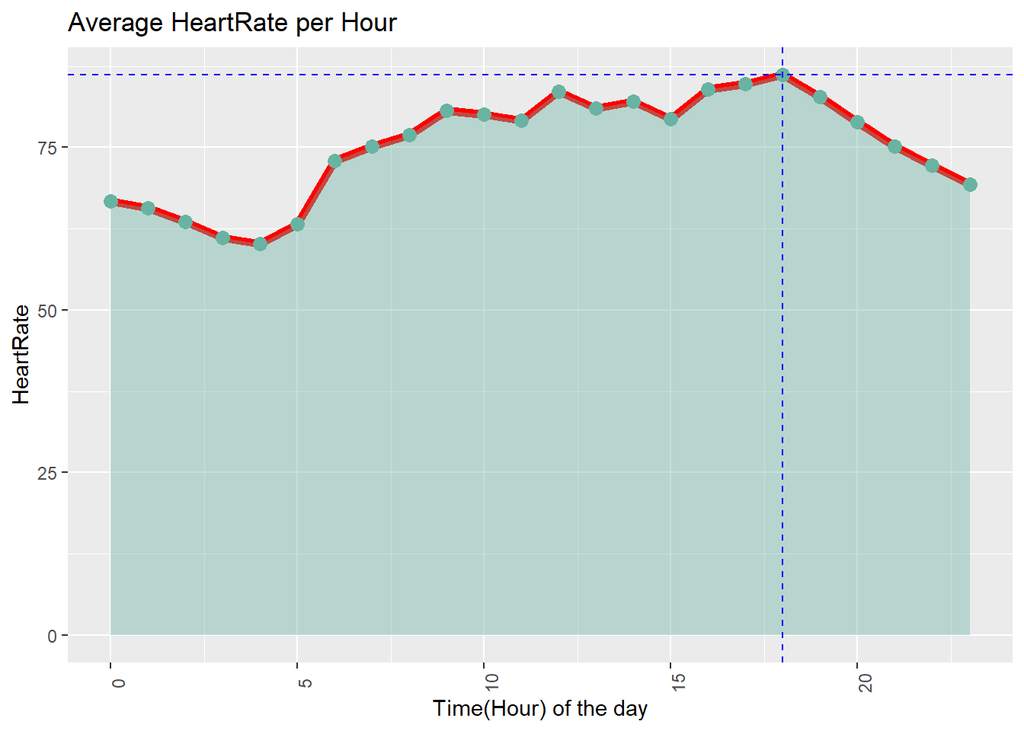

```r
#Analyze the heaartrate per hour throughta day
heartrate_hour <- heartrate_clean %>%
  mutate(day_hour = hour(time))

heartrate_hour <- heartrate_hour %>%
  group_by(day_hour) %>%
  summarize(avg = round(mean(Value),digit = 2))

#Create plot for average HeartRate per Day
ggplot(data = heartrate_hour, aes(x = day_hour, y = avg,))+
  geom_line(stat = "identity", color = "red", size = 2)+
  labs(title = "Average HeartRate per Hour", x= "Time(Hour) of the day", y= "HeartRate", )+
  geom_area( fill="#69b3a2", alpha=0.4)+
  geom_point(size=3, color="#69b3a2") +
  theme(axis.text.x = element_text(angle = 90))+
  expand_limits(x = 0, y = 0)+
  geom_hline(yintercept = 86.13, linetype = "dashed", color = "blue")+
  geom_vline(xintercept = 18, linetype = "dashed", color = "blue")
```

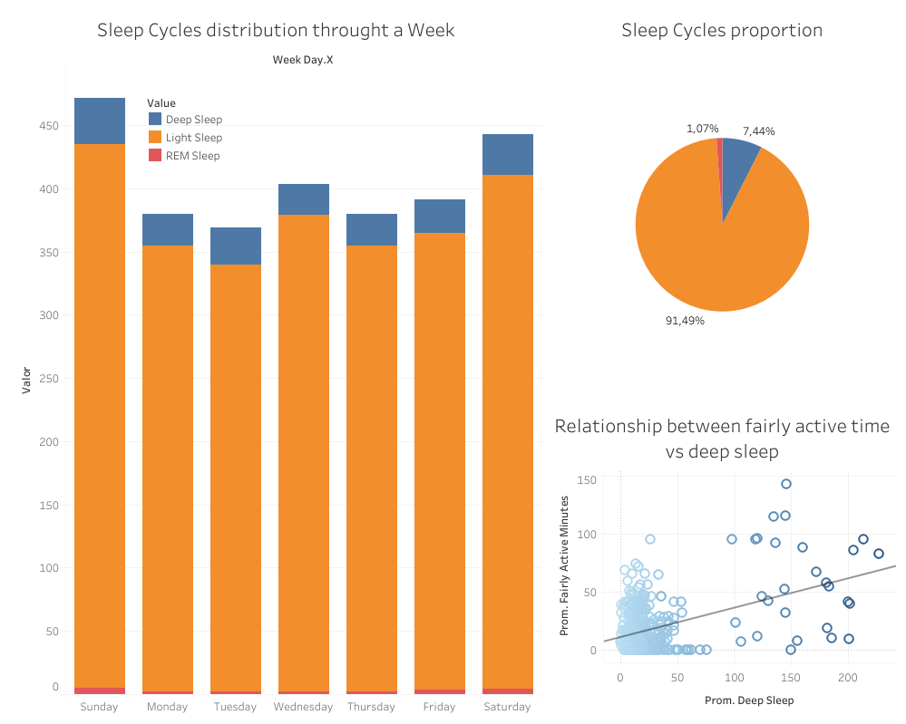

```r
#Merge sleep and activity observations to look for any correlation factor
daily_act_clean <- rename(daily_act_clean, date = fixed_date )
sleep_clean <- rename(sleep_clean, date = date_time)
d_act_sleep_merged <- merge(daily_act_clean, sleep_clean, by = c('Id', 'date'))
colnames(d_act_sleep_merged)
```

```
##  [1] "Id"                       "date"
##  [3] "week_day.x"               "TotalSteps"
##  [5] "TotalDistance"            "TrackerDistance"
##  [7] "LoggedActivitiesDistance" "VeryActiveDistance"
##  [9] "ModeratelyActiveDistance" "LightActiveDistance"
## [11] "SedentaryActiveDistance"  "VeryActiveMinutes"
## [13] "FairlyActiveMinutes"      "LightlyActiveMinutes"
## [15] "SedentaryMinutes"         "Calories"
## [17] "time_logged_mins"         "time_logged_hours"
## [19] "week_day.y"               "TotalMinutesAsleep"
## [21] "TotalTimeInBed"           "totaltime_awake"
## [23] "TotalSleepRecords"
```

```r
drops <- c("TrackerDistance", "LoggedActivitiesDistance", "VeryActiveDistance",
           "ModeratelyActiveDistance", "LightActiveDistance", "SedentaryActiveDistance",
           "time_logged_mins", "time_logged_hours", "week_day.y", "TotalSleepRecords")
d_act_sleep_merged <- d_act_sleep_merged[ , !(names(d_act_sleep_merged) %in% drops)]
colnames(d_act_sleep_merged)
```

```
##  [1] "Id"                   "date"                 "week_day.x"
##  [4] "TotalSteps"           "TotalDistance"        "VeryActiveMinutes"
##  [7] "FairlyActiveMinutes"  "LightlyActiveMinutes" "SedentaryMinutes"
## [10] "Calories"             "TotalMinutesAsleep"   "TotalTimeInBed"
## [13] "totaltime_awake"
```

```r
d_act_sleep_merged <- d_act_sleep_merged %>%
  filter(TotalMinutesAsleep > 200) %>%
  filter(TotalSteps >= 100)

#Looking for the average light sleep time in minutes and hours
summary_sleep[is.na(summary_sleep)] <- 0
summary_sleep_cycle <- summary_sleep %>%
  select(avg_light, avg_deep, avg_rem) %>%
  filter(avg_light >200) %>%
  summarize(avg_light = (mean(avg_light)/60), avg_deep = (mean(avg_deep)/60),
            avg_rem = (mean(avg_rem)/60))
head(summary_sleep_cycle)
```

```
##   avg_light avg_deep avg_rem
## 1       NaN      NaN     NaN
```

```r
#Preparing Mets Dataframe for merging
mets_analysis<- mets_clean %>%
  group_by(date, Id) %>%
  summarize(total_mets = sum(METs))
head(mets_analysis)
```

```
## # A tibble: 6 x 3
## # Groups:   date [1]
##   date               Id total_mets
##   <date>          <dbl>      <int>
## 1 2016-04-12 1503960366      25241
## 2 2016-04-12 1624580081      17234
## 3 2016-04-12 1644430081      22768
## 4 2016-04-12 1844505072      21704
## 5 2016-04-12 1927972279      15599
## 6 2016-04-12 2022484408      23035
```

```r
#Merging Activities, METs and Sleep Cycle dataframes

correlation_sleep_cycle <- wide_sleep %>%
  filter(`Light Sleep` >200)

df_analysis <- merge(d_act_sleep_merged, correlation_sleep_cycle, by = c('Id', 'date'))
colnames(df_analysis)
```

```
##  [1] "Id"                   "date"                 "week_day.x"
##  [4] "TotalSteps"           "TotalDistance"        "VeryActiveMinutes"
##  [7] "FairlyActiveMinutes"  "LightlyActiveMinutes" "SedentaryMinutes"
## [10] "Calories"             "TotalMinutesAsleep"   "TotalTimeInBed"
## [13] "totaltime_awake"      "logId"                "Light Sleep"
## [16] "Deep Sleep"           "REM Sleep"
```

```r
df_analysis <- merge(df_analysis, mets_analysis, by = c('Id', 'date'))
colnames(df_analysis)
```

```
##  [1] "Id"                   "date"                 "week_day.x"
##  [4] "TotalSteps"           "TotalDistance"        "VeryActiveMinutes"
##  [7] "FairlyActiveMinutes"  "LightlyActiveMinutes" "SedentaryMinutes"
## [10] "Calories"             "TotalMinutesAsleep"   "TotalTimeInBed"
## [13] "totaltime_awake"      "logId"                "Light Sleep"
## [16] "Deep Sleep"           "REM Sleep"            "total_mets"
```

```r
#Dropping unnecessary fields for the analysis
drops <- c("week_day.x", "TotalMinutesAsleep", "TotalTimeInBed",
           "totaltime_awake", "logId")
df_analysis <- df_analysis[ , !(names(df_analysis) %in% drops)]
colnames(df_analysis)
```

```
##  [1] "Id"                   "date"                 "TotalSteps"
##  [4] "TotalDistance"        "VeryActiveMinutes"    "FairlyActiveMinutes"
##  [7] "LightlyActiveMinutes" "SedentaryMinutes"     "Calories"
## [10] "Light Sleep"          "Deep Sleep"           "REM Sleep"
## [13] "total_mets"
```

```r
#Creating a Pearson Correlation Matrix
mydata2 <- df_analysis[, c(3:13)]
head(mydata2)
```

```
##   TotalSteps TotalDistance VeryActiveMinutes FairlyActiveMinutes
## 1      13162          8.50                25                  13
## 2      10735          6.97                21                  19
## 3       9762          6.28                29                  34
## 4      12669          8.16                36                  10
## 5       9705          6.48                38                  20
## 6      15506          9.88                50                  31
##   LightlyActiveMinutes SedentaryMinutes Calories Light Sleep Deep Sleep
## 1                  328              728     1985         327         13
## 2                  217              776     1797         290         11
## 3                  209              726     1745         412         22
## 4                  221              773     1863         270         16
## 5                  164              539     1728         668         11
## 6                  264              775     2035         304         16
##   REM Sleep total_mets
## 1         6      25241
## 2        12      22859
## 3         8      22190
## 4         3      23694
## 5         0      21972
## 6         0      25883
```

```r
corr_df_analysis <- round(cor(mydata2), 2)
head(corr_df_analysis)
```

```
##                      TotalSteps TotalDistance VeryActiveMinutes
## TotalSteps                 1.00          0.98              0.55
## TotalDistance              0.98          1.00              0.59
## VeryActiveMinutes          0.55          0.59              1.00
## FairlyActiveMinutes        0.56          0.55              0.32
## LightlyActiveMinutes       0.39          0.36             -0.23
## SedentaryMinutes          -0.15         -0.15             -0.01
##                      FairlyActiveMinutes LightlyActiveMinutes SedentaryMinutes
## TotalSteps                          0.56                 0.39            -0.15
## TotalDistance                       0.55                 0.36            -0.15
## VeryActiveMinutes                   0.32                -0.23            -0.01
## FairlyActiveMinutes                 1.00                -0.04            -0.03
## LightlyActiveMinutes               -0.04                 1.00            -0.36
## SedentaryMinutes                   -0.03                -0.36             1.00
##                      Calories Light Sleep Deep Sleep REM Sleep total_mets
## TotalSteps               0.40       -0.22       0.13     -0.11       0.77
## TotalDistance            0.52       -0.23       0.10     -0.11       0.79
## VeryActiveMinutes        0.63       -0.26      -0.07     -0.04       0.72
## FairlyActiveMinutes      0.17       -0.20       0.44     -0.06       0.46
## LightlyActiveMinutes     0.07        0.10      -0.12     -0.05       0.36
## SedentaryMinutes         0.04       -0.43      -0.04     -0.17      -0.02
```

```r
melted_corr_df_analysis <- melt(corr_df_analysis)
head(melted_corr_df_analysis)
```

```
##                   Var1       Var2 value
## 1           TotalSteps TotalSteps  1.00
## 2        TotalDistance TotalSteps  0.98
## 3    VeryActiveMinutes TotalSteps  0.55
## 4  FairlyActiveMinutes TotalSteps  0.56
## 5 LightlyActiveMinutes TotalSteps  0.39
## 6     SedentaryMinutes TotalSteps -0.15
```

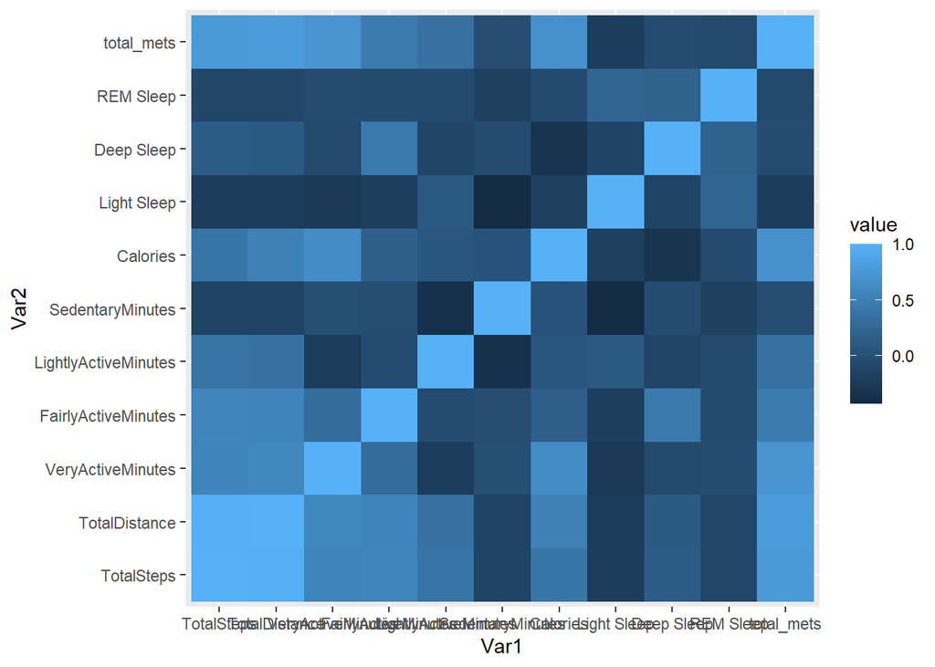

```r
ggplot(data = melted_corr_df_analysis, aes(Var1, y = Var2, fill = value))+
  geom_tile()
```

```r
# Get lower triangle of the correlation matrix
get_lower_tri<-function(corr_df_analysis){
  corr_df_analysis[upper.tri(corr_df_analysis)] <- NA
  return(corr_df_analysis)
}

# Get upper triangle of the correlation matrix
get_upper_tri <- function(corr_df_analysis){
  corr_df_analysis[lower.tri(corr_df_analysis)]<- NA
  return(corr_df_analysis)
}

upper_tri <- get_upper_tri(corr_df_analysis)
upper_tri
```

```
##                      TotalSteps TotalDistance VeryActiveMinutes
## TotalSteps                    1          0.98              0.55
## TotalDistance                NA          1.00              0.59
## VeryActiveMinutes            NA            NA              1.00
## FairlyActiveMinutes          NA            NA                NA
## LightlyActiveMinutes         NA            NA                NA
## SedentaryMinutes             NA            NA                NA
## Calories                     NA            NA                NA
## Light Sleep                  NA            NA                NA
## Deep Sleep                   NA            NA                NA
## REM Sleep                    NA            NA                NA
## total_mets                   NA            NA                NA
##                      FairlyActiveMinutes LightlyActiveMinutes SedentaryMinutes
## TotalSteps                          0.56                 0.39            -0.15
## TotalDistance                       0.55                 0.36            -0.15
## VeryActiveMinutes                   0.32                -0.23            -0.01
## FairlyActiveMinutes                 1.00                -0.04            -0.03
## LightlyActiveMinutes                  NA                 1.00            -0.36
## SedentaryMinutes                      NA                   NA             1.00
## Calories                              NA                   NA               NA
## Light Sleep                           NA                   NA               NA
## Deep Sleep                            NA                   NA               NA
## REM Sleep                             NA                   NA               NA
## total_mets                            NA                   NA               NA
##                      Calories Light Sleep Deep Sleep REM Sleep total_mets
## TotalSteps               0.40       -0.22       0.13     -0.11       0.77
## TotalDistance            0.52       -0.23       0.10     -0.11       0.79
## VeryActiveMinutes        0.63       -0.26      -0.07     -0.04       0.72
## FairlyActiveMinutes      0.17       -0.20       0.44     -0.06       0.46
## LightlyActiveMinutes     0.07        0.10      -0.12     -0.05       0.36
## SedentaryMinutes         0.04       -0.43      -0.04     -0.17      -0.02
## Calories                 1.00       -0.18      -0.32     -0.05       0.68
## Light Sleep                NA        1.00      -0.13      0.23      -0.21
## Deep Sleep                 NA          NA       1.00      0.20      -0.04
## REM Sleep                  NA          NA         NA      1.00      -0.07
## total_mets                 NA          NA         NA        NA       1.00
```

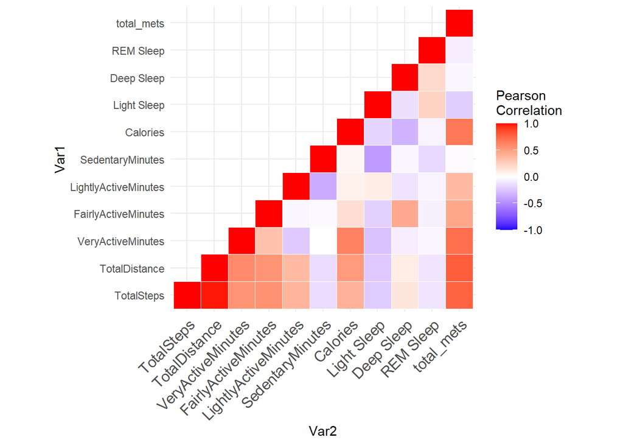

```r
# Melt the correlation matrix
melted_corr_df_analysis<- melt(upper_tri, na.rm = TRUE)
# Heatmap
ggplot(data = melted_corr_df_analysis, aes(Var2, Var1, fill = value))+
  geom_tile(color = "white")+
  scale_fill_gradient2(low = "blue", high = "red", mid = "white",
                       midpoint = 0, limit = c(-1,1), space = "Lab",
                       name="Pearson\nCorrelation") +
  theme_minimal()+
  theme(axis.text.x = element_text(angle = 45, vjust = 1,
                                   size = 12, hjust = 1))+
  coord_fixed()
```

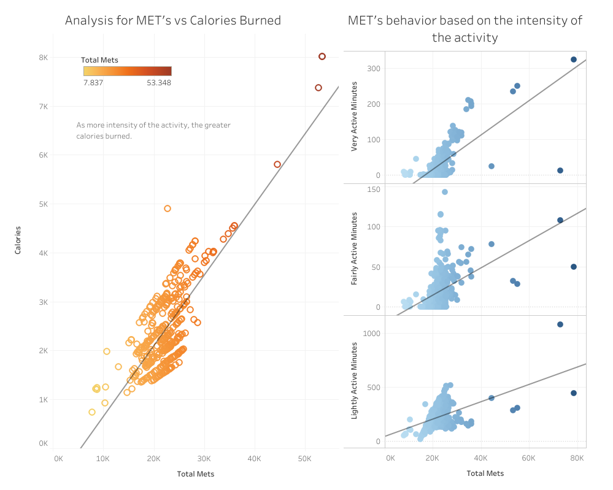

METs Analysis based on Calories and Activities

```r
#Convert the analysis data frame into a CSV file in order to create
#visualizations in TABLEU

write.csv(df_analysis, file = "bellabeat_viz.csv")
```

- *Findings:*
  - There is a positive relationship between the Very Active Minutes and the Calories burned by users, which means the more time users spend in daily doing activities (cleaning, walking the dog, gardening) or daily exercise, leads to a greater amount of calories burned.
  - There is negative relationship between the Sedentary Minutes and Total Minutes Asleep. Many research have concluded that sedentary is strongly associated with sleep problems such as insomnia or cases of sleep disturbance, and could be directly involved with issues with the sleep cycles of the users (disturbances in sleep stages).
  - Total Distance and variables related to activities, share a strong relationship, which means user have a common pattern of burning calories completing activities like walking or jogging, rather than spending most of this time doing exercises like weight lifting.

## *Applying trends to Bellabeat customers*

Bellabeat customer are woman who are interested in their health care, that’s the main reason for them to purchase this kind of smart devices. The previous statement are mandatory facts that may greatly influence one person habits which directly reflects in their health and well being. As a company committed with our users interests, that’s why taking this behavioral data is important in order to develop new features that understand customers needs and helps them fix bad habits and improve their health.

## *Marketing Strategies*

Creating campaigns that promotes the benefits of a good sleep cycle in our daily life, introducing our customers new features that will help them create a proper sleep schedule and alignment of the circadian rhythm.

Promote user community activities on weekends, prompting customers performing different light, fair and intense activities, to create awareness of their impact on calories burnt to balance the calories intake.